# Missing Value Imputation

### B.4 MICE Imputation

There has been numerous journals and papers published, and they are cited as reference, in case one wants to dive into the depth. I will be touching the preliminary concepts required:

#### B.4.1 MICE algorithm

**MICE** Multiple Imputation by Chained Equations

**Step 1** : Impute all the missing values, think of it has “placeholders”

**Step 2** : Pick one var1, remove the placeholders, var1 has both *observed* and *missing*

**Step 3** : Run regression on observed values of **var1** as response variable, and other variables as predictors(sometimes all or subset of the variables are used for the prediction).

**Step 4** : Use the above model to predict the missing values. - When the above **var1** is used as independent variable, both the observed and imputed values will be used to train the model.

**Step 5** : Step 2 to Step 4 is repeated for every variable which has missing values.

**Step 6**: The above steps run for mutiple iterations, as in Step 3 not all the variables have been picked. It tries to run many iterations to store as much imouted values it can, just like radnom forest works. Do boot strapping and estimate as much as trees as we want, so that we all the pssible combinations of variables.

#### B.4.2 MICE Imputation in R

```r
set.seed(1234)
air.imputed.mice <- mice(air,m=1, maxit=3, meth="pmm")
#summary(air.imputed.mice)
```

Lets see what does all the parameter means:

- **m** : number of imputed datasets
- **maxit**: number of iterations (cycles from Step 2- Step 4) one wants to run (generally keep it low, when the dataset is big)
- **meth**: meth stands for method, i.e. there are multiple methods available
  - *pmm*: predictive mean matching
  - *rf*: rando forest imputation
  - *cart*: classification or regression trees

We can run summary of the data set just obtained, however its little difficult to read it, hence omitted that step in output.

#### B.4.3 MICE Imputation complete function

We can use **complete** function to call which imputed data set we want to use

- if we want **1st data set**, use complete with **parameter 1**
- if we want the **2nd data set**, use complete with **paramter 2**

#### B.4.4 MICE Imputation distribution check

Its nice to check how the observed and imouted values looks like:

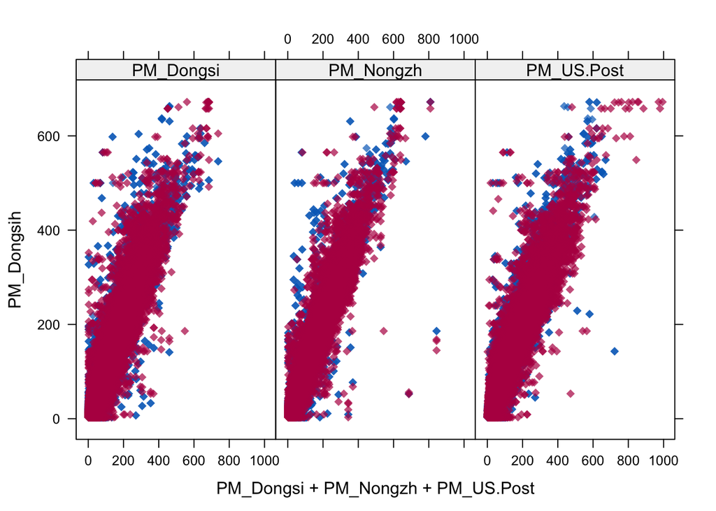

```r
xyplot(air.imputed.mice,PM_Dongsih ~ PM_Dongsi+PM_Nongzh+PM_US.Post,pch=18,cex=1)
```

The red dots represents the imputed values, while the blue dots represnts the observed values. From the graph, it is clear that imputed values have same shape as of observed values with respect to other variables.

Thank you for reading the article.

**The first 3 papers mentioned in the references are great, and I highly recommned it to read if someone wants to master the art of imputation.**

## References

1. https://www.ncbi.nlm.nih.gov/pmc/articles/PMC3074241/
2. https://www.ncbi.nlm.nih.gov/pmc/articles/PMC4121561/
3. https://www.ncbi.nlm.nih.gov/pmc/articles/PMC4701517/
4. http://r-statistics.co/Missing-Value-Treatment-With-R.html
5. https://datascienceplus.com/imputing-missing-data-with-r-mice-package/